# BankChurners

**Adaboost with Original data**

```python
# Defining the model.
Ada_org = AdaBoostClassifier(random_state=1)

# Creating the parameter grid to pass in RandomSearchCV.
param_grid = {
          "n_estimators": np.arange(50,110,25),
          "learning_rate": [0.01,0.1,0.05],
          "estimator": [  # Changed 'base_estimator' to 'estimator'
        DecisionTreeClassifier(max_depth=2, random_state=1),
        DecisionTreeClassifier(max_depth=3, random_state=1),]
}

# Defining the scorer.
scorer = make_scorer(precision_score)

# Calling RandomizedSearchCV.
randomized_cv = RandomizedSearchCV(estimator=Ada_org, param_distributions=param_grid, n_iter=10, n_jobs = -1, scoring=scorer, cv=5, random_state=1)

# Fitting parameters in RandomizedSearchCV.
randomized_cv.fit(X_train,y_train)

# Printing the best parameters from from the RandomizedSearchCV.
print("Best parameters are {} with CV score={}:" .format(randomized_cv.best_params_,randomized_cv.best_score_))
```

```
Best parameters are {'n_estimators': 75, 'learning_rate': 0.1, 'estimator': DecisionTreeClassifier(max_depth=2, random_state=1)} with CV score=0.9201731873857171:
```

**The best parameter- estimators is 75, learning rate 0.1, the estimator is decision tree with max depth 2 and random state =1**

```python
## Creating the tuned model with the best parameters found in RandomizedSearchCV.
Ada_org_tuned = AdaBoostClassifier(
    random_state=1,
    n_estimators=100,
    learning_rate=0.1,
    estimator=DecisionTreeClassifier(max_depth=3, random_state=1)) # Changed 'base_estimator' to 'estimator'

# Fitting the model to the original training data.
Ada_org_tuned.fit(X_train, y_train)
```

```
AdaBoostClassifier(estimator=DecisionTreeClassifier(max_depth=3,
                                                    random_state=1),
                   learning_rate=0.1, n_estimators=100, random_state=1)
```

```python
# Checking the tuned model's performance metrics on the original training data.
model_performance_classification_sklearn(Ada_org_tuned, X_train, y_train)
```

|  | Accuracy | Recall | Precision | F1 |
| --- | --- | --- | --- | --- |
| 0 | 0.982222 | 0.927254 | 0.960722 | 0.943691 |

```python
# Saving the tuned model's scores for later comparison.
Ada_org_tuned_train_scores = model_performance_classification_sklearn(Ada_org_tuned, X_train, y_train)
```

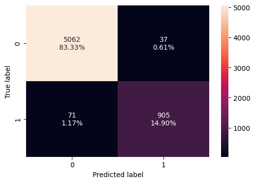

```python
# Creating the confusion matrix for the tuned model's performance on the original training data.
confusion_matrix_sklearn(Ada_org_tuned, X_train, y_train)
```

```python
# Checking the tuned model's performance metrics on the validation data.
model_performance_classification_sklearn(Ada_org_tuned, X_val, y_val)
```

|  | Accuracy | Recall | Precision | F1 |
| --- | --- | --- | --- | --- |
| 0 | 0.96693 | 0.855828 | 0.93311 | 0.8928 |

```python
# Saving the tuned model's scores for later comparison.
Ada_org_tuned_val_scores = model_performance_classification_sklearn(Ada_org_tuned, X_val, y_val)
```

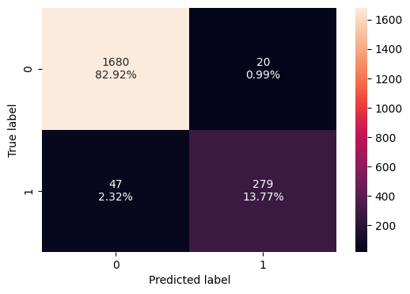

```python
#Creating the confusion matrix for the tuned model's performance on the validation data.
confusion_matrix_sklearn(Ada_org_tuned, X_val, y_val)
```

Adaboost Model gives 96% ACCURACY, 85% RECALL , Precision 93% and F1 score with 89% for the original data

**The best parameter- estimators is 75, learning rate 0.1, the estimator is decision tree with max depth 2 and random state =1**

**Models Built on oversampled data**

**XGBoost in Oversample Training Data**

```python
# Defining the model.
XGB_over = XGBClassifier(random_state=1)

# Creating the parameter grid to pass in RandomSearchCV.
param_grid={'n_estimators':np.arange(50,110,25),
            'scale_pos_weight':[1,2,5],
            'learning_rate':[0.01,0.1,0.05],
            'gamma':[1,3],
            'subsample':[0.7,0.9]
}

# Defining the scorer.
scorer = make_scorer(precision_score)

# Calling RandomizedSearchCV.
randomized_cv = RandomizedSearchCV(estimator=XGB_over, param_distributions=param_grid, n_iter=10, n_jobs = -1, scoring=scorer, cv=5, random_state=1)

# Fitting the parameters in RandomizedSearchCV.
randomized_cv.fit(X_train_over,y_train_over)

# Printing the best parameters from from the RandomizedSearchCV.
print("Best parameters are {} with CV score={}:" .format(randomized_cv.best_params_,randomized_cv.best_score_))
```

```
Best parameters are {'subsample': 0.7, 'scale_pos_weight': 1, 'n_estimators': 100, 'learning_rate': 0.05, 'gamma': 1} with CV score=0.9685717175012417:
```

**XGBoost model for over sampling works better with best hyper parameter such as estimator = 100, learning rate =0.05, gamma =1**

**The randomizedsearchcv is used for scaling**

```python
# Creating the tuned model with the best parameters found in RandomizedSearchCV.
XGB_over_tuned = XGBClassifier(
    random_state=1,
    subsample=0.7,
    scale_pos_weight=1,
    n_estimators=100,
    learning_rate=0.05,
    gamma=1)

# Fitting the tuned model to the oversampled traning data.
XGB_over_tuned.fit(X_train_over, y_train_over)
```

```
XGBClassifier(base_score=None, booster=None, callbacks=None,
              colsample_bylevel=None, colsample_bynode=None,
              colsample_bytree=None, device=None, early_stopping_rounds=None,
              enable_categorical=False, eval_metric=None, feature_types=None,
              gamma=1, grow_policy=None, importance_type=None,
              interaction_constraints=None, learning_rate=0.05, max_bin=None,
              max_cat_threshold=None, max_cat_to_onehot=None,
              max_delta_step=None, max_depth=None, max_leaves=None,
              min_child_weight=None, missing=nan, monotone_constraints=None,
              multi_strategy=None, n_estimators=100, n_jobs=None,
              num_parallel_tree=None, random_state=1, ...)
```

```python
# Saving the tuned model's scores for later comparison.
XGB_over_tuned_train_scores = model_performance_classification_sklearn(XGB_over_tuned, X_train_over, y_train_over)
```

```python
# Checking the tuned model's performance metrics on the oversampled training data.
model_performance_classification_sklearn(XGB_over_tuned, X_train_over, y_train_over)
```

|  | Accuracy | Recall | Precision | F1 |
| --- | --- | --- | --- | --- |
| 0 | 0.986958 | 0.990979 | 0.983074 | 0.98701 |

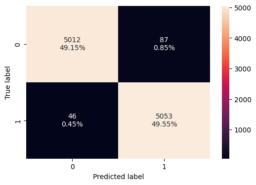

```python
# Creating the confusion matrix for the tuned model's performance on the oversampled training data.
confusion_matrix_sklearn(XGB_over_tuned, X_train_over, y_train_over)
```

```python
# Checking the tuned model's performance metrics on the validation data.
model_performance_classification_sklearn(XGB_over_tuned, X_val, y_val)
```

|  | Accuracy | Recall | Precision | F1 |
| --- | --- | --- | --- | --- |
| 0 | 0.957058 | 0.907975 | 0.838527 | 0.87187 |

**The aCCURACY IS 95%, RECALL WITH 90% PRECISION 83% AND F1 SCORE WITH 87%**

```python
# Saving the tuned model's scores for later comparison.
XGB_over_tuned_val_scores = model_performance_classification_sklearn(XGB_over_tuned, X_val, y_val)
```

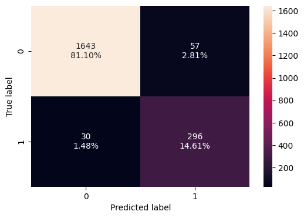

```python
# Creating the confusion matrix for the tuned model's performance on the validation data.
confusion_matrix_sklearn(XGB_over_tuned, X_val, y_val)
```

**The aCCURACY IS 95%, RECALL WITH 90% PRECISION 83% AND F1 SCORE WITH 87%**

**XGBoost model for over sampling works better with best hyper parameter such as estimator = 100, learning rate =0.05, gamma =1**

**The randomizedsearchcv is used for scaling**

**Adaboost in Oversampled Training Data**

```python
# Defining the model.
Ada_over = AdaBoostClassifier(random_state=1)

# Creating the parameter grid to pass in RandomSearchCV.
param_grid = {
          "n_estimators": np.arange(50,110,25),
          "learning_rate": [0.01,0.1,0.05],
          "estimator": [  # Changed 'base_estimator' to 'estimator'
        DecisionTreeClassifier(max_depth=2, random_state=1),
        DecisionTreeClassifier(max_depth=3, random_state=1),]
}

# Defining the scorer.
scorer = make_scorer(precision_score)

# Calling RandomizedSearchCV.
randomized_cv = RandomizedSearchCV(estimator=Ada_over, param_distributions=param_grid, n_iter=10, n_jobs = -1, scoring=scorer, cv=5, random_state=1)

# Fitting parameters in RandomizedSearchCV.
randomized_cv.fit(X_train_over,y_train_over)

# Printing the best parameters from from the RandomizedSearchCV.
print("Best parameters are {} with CV score={}:" .format(randomized_cv.best_params_,randomized_cv.best_score_))
```

```
Best parameters are {'n_estimators': 100, 'learning_rate': 0.1, 'estimator': DecisionTreeClassifier(max_depth=3, random_state=1)} with CV score=0.9832806769641115:
```

**Adaboost Model in oversampling gives best result with hyper parameters estimator = 100, learning rate 0.1, estimator with max depth = 3 and random state = 1**

```python
# Creating the tuned model with the best parameters found in RandomizedSearchCV.
Ada_over_tuned = AdaBoostClassifier(
    random_state=1,
    n_estimators=100,
    learning_rate=0.1,
    estimator=DecisionTreeClassifier(max_depth=3, random_state=1)) # Changed 'base_estimator' to 'estimator'

# Fitting the model to the oversampled training data.
Ada_over_tuned.fit(X_train_over, y_train_over)
```

```
AdaBoostClassifier(estimator=DecisionTreeClassifier(max_depth=3,
                                                    random_state=1),
                   learning_rate=0.1, n_estimators=100, random_state=1)
```

```python
# Checking the tuned model's performance metrics on the oversampled training data.
model_performance_classification_sklearn(Ada_over_tuned, X_train_over, y_train_over)
```

|  | Accuracy | Recall | Precision | F1 |
| --- | --- | --- | --- | --- |
| 0 | 0.987154 | 0.985095 | 0.989169 | 0.987128 |

The accuracy with 98%, 98.5 recall, 98.9Precision and 98.7 F1 score

```python
# Saving the tuned model's scores for later comparison.
Ada_over_tuned_train_scores = model_performance_classification_sklearn(Ada_over_tuned, X_train_over, y_train_over)
```

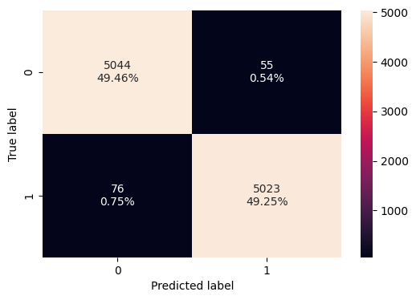

```python
# Creating the confusion matrix for the tuned model's performance on the oversampled training data.
confusion_matrix_sklearn(Ada_over_tuned, X_train_over, y_train_over)
```

**The accuracy with 98%, 98.5 recall, 98.9Precision and 98.7 F1 score**

**Adaboost Model in oversampling gives best result with hyper parameters estimator = 100, learning rate 0.1, estimator with max depth = 3 and random state = 1**

**Gradient Boost in oversampled training data**

```python
# Defining the model.
GBC_over = GradientBoostingClassifier(random_state=1)

# Creating the parameter grid to pass in RandomSearchCV.
param_grid={"init": [AdaBoostClassifier(random_state=1),DecisionTreeClassifier(random_state=1)],
            "n_estimators": np.arange(50,110,25),
            "learning_rate": [0.01,0.1,0.05],
            "subsample":[0.7,0.9],
            "max_features":[0.5,0.7,1],
}
# Defining the scorer.
scorer = make_scorer(precision_score)

# Calling RandomizedSearchCV.
randomized_cv = RandomizedSearchCV(estimator=GBC_over, param_distributions=param_grid, n_iter=10, n_jobs = -1, scoring=scorer, cv=5, random_state=1)

# Fitting the parameters in RandomizedSearchCV.
randomized_cv.fit(X_train_over,y_train_over)

# Printing the best parameters from from the RandomizedSearchCV.
print("Best parameters are {} with CV score={}:" .format(randomized_cv.best_params_,randomized_cv.best_score_))
```

```
Best parameters are {'subsample': 0.7, 'n_estimators': 100, 'max_features': 0.7, 'learning_rate': 0.05, 'init': DecisionTreeClassifier(random_state=1)} with CV score=0.9406330715336446:
```

```python
# Creating the tuned model with the best parameters found in RandomizedSearchCV.
GBC_over_tuned = GradientBoostingClassifier(
    random_state=1,
    subsample=0.7,
    n_estimators=100,
    max_features=0.7,
    learning_rate=0.05,
    init=DecisionTreeClassifier(random_state=1))

# Fitting the model to the original training data.
GBC_over_tuned.fit(X_train_over, y_train_over)
```

```
GradientBoostingClassifier(init=DecisionTreeClassifier(random_state=1),
                           learning_rate=0.05, max_features=0.7, random_state=1,
                           subsample=0.7)
```

```python
# Checking the tuned model's performance metrics on the oversampled training data.
model_performance_classification_sklearn(GBC_over_tuned, X_train_over, y_train_over)
```

|  | Accuracy | Recall | Precision | F1 |
| --- | --- | --- | --- | --- |
| 0 | 1.0 | 1.0 | 1.0 | 1.0 |

```python
# Saving the tuned model's scores for later comparison.
GBC_over_tuned_train_scores = model_performance_classification_sklearn(GBC_over_tuned, X_train_over, y_train_over)
```

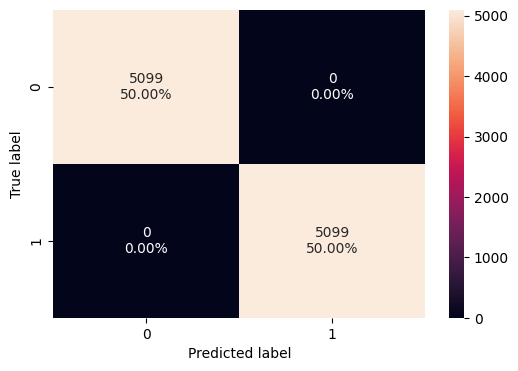

```python
# Creating the confusion matrix for the tuned model's performance on the oversampled training data.
confusion_matrix_sklearn(GBC_over_tuned, X_train_over, y_train_over)
```

```python
# Checking the tuned model's performance metrics on the validation data.
model_performance_classification_sklearn(GBC_over_tuned, X_val, y_val)
```

|  | Accuracy | Recall | Precision | F1 |
| --- | --- | --- | --- | --- |
| 0 | 0.920039 | 0.831288 | 0.716931 | 0.769886 |

```python
# Saving the tuned model's scores for later comparison.
GBC_over_tuned_val_scores = model_performance_classification_sklearn(GBC_over_tuned, X_val, y_val)
```

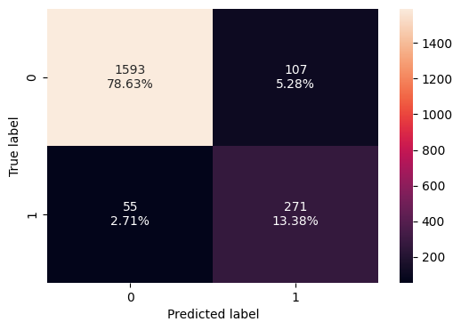

```python
# Creating the confusion matrix for the tuned model's performance on the validation data.
confusion_matrix_sklearn(GBC_over_tuned, X_val, y_val)
```

**Model Build on undersampled data**

```python
# Defining the model.
GBC_un = GradientBoostingClassifier(random_state=1)

# Creating the parameter grid to pass in RandomSearchCV.
param_grid={"init": [AdaBoostClassifier(random_state=1),DecisionTreeClassifier(random_state=1)],
            "n_estimators": np.arange(50,110,25),
            "learning_rate": [0.01,0.1,0.05],
            "subsample":[0.7,0.9],
            "max_features":[0.5,0.7,1],
}
# Defining the scorer.
scorer = make_scorer(precision_score)

# Calling RandomizedSearchCV.
randomized_cv = RandomizedSearchCV(estimator=GBC_un, param_distributions=param_grid, n_iter=10, n_jobs = -1, scoring=scorer, cv=5, random_state=1)

# Fitting the parameters in RandomizedSearchCV.
randomized_cv.fit(X_train_un,y_train_un)

# Printing the best parameters from from the RandomizedSearchCV.
print("Best parameters are {} with CV score={}:" .format(randomized_cv.best_params_,randomized_cv.best_score_))
```

```
Best parameters are {'subsample': 0.7, 'n_estimators': 100, 'max_features': 0.7, 'learning_rate': 0.05, 'init': DecisionTreeClassifier(random_state=1)} with CV score=0.8989518429005287:
```

```python
# Creating the tuned model with the best parameters found in RandomizedSearchCV.
GBC_un_tuned = GradientBoostingClassifier(
    random_state=1,
    subsample=0.7,
    n_estimators=100,
    max_features=0.7,
    learning_rate=0.05,
    init=DecisionTreeClassifier(random_state=1))

# Fitting the model to the undersampled training data.
GBC_un_tuned.fit(X_train_un, y_train_un)
```

```
GradientBoostingClassifier(init=DecisionTreeClassifier(random_state=1),
                           learning_rate=0.05, max_features=0.7, random_state=1,
                           subsample=0.7)
```

```python
# Checking the tuned model's performance metrics on the undersampled training data.
model_performance_classification_sklearn(GBC_un_tuned, X_train_un, y_train_un)
```

|  | Accuracy | Recall | Precision | F1 |
| --- | --- | --- | --- | --- |
| 0 | 1.0 | 1.0 | 1.0 | 1.0 |

```python
# Saving the tuned model's scores for later comparison.
GBC_un_tuned_train_scores = model_performance_classification_sklearn(GBC_un_tuned, X_train_un, y_train_un)
```

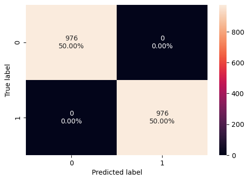

```python
# Creating the confusion matrix for the tuned model's performance on the undersampled training data.
confusion_matrix_sklearn(GBC_un_tuned, X_train_un, y_train_un)
```

```python
# Checking the tuned model's performance metrics on the validation data.
model_performance_classification_sklearn(GBC_un_tuned, X_val, y_val)
```

|  | Accuracy | Recall | Precision | F1 |
| --- | --- | --- | --- | --- |
| 0 | 0.89536 | 0.920245 | 0.617284 | 0.738916 |

```python
# Saving the tuned model's scores for later comparison.
GBC_un_tuned_val_scores = model_performance_classification_sklearn(GBC_un_tuned, X_val, y_val)
```

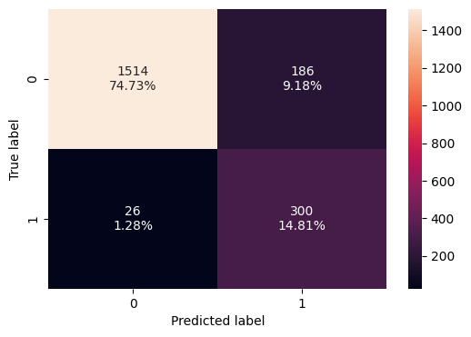

```python
# Creating the confusion matrix for the tuned model's performance on the validation data.
confusion_matrix_sklearn(GBC_un_tuned, X_val, y_val)
```

**RandomForest in Undersampled Training Data**

```python
# Defining the model.
RF_un = RandomForestClassifier(random_state=1)

# Creating the parameter grid to pass in RandomSearchCV.
param_grid={
    "n_estimators": [50,110,25],
    "min_samples_leaf": np.arange(1, 4),
    "max_features": [np.arange(0.3, 0.6, 0.1),'sqrt'],
    "max_samples": np.arange(0.4, 0.7, 0.1)
}

# Defining the scorer.
scorer = make_scorer(precision_score)

# Calling RandomizedSearchCV.
randomized_cv = RandomizedSearchCV(estimator=RF_un, param_distributions=param_grid, n_iter=10, n_jobs = -1, scoring=scorer, cv=5, random_state=1)

# Fitting the parameters in RandomizedSearchCV.
randomized_cv.fit(X_train_un,y_train_un)

# Printing the best parameters from from the RandomizedSearchCV.
print("Best parameters are {} with CV score={}:" .format(randomized_cv.best_params_,randomized_cv.best_score_))
```

```
Best parameters are {'n_estimators': 110, 'min_samples_leaf': 1, 'max_samples': 0.6, 'max_features': 'sqrt'} with CV score=0.9165800198180009:
```

```python
# Creating the tuned model with the best parameters found in RandomizedSearchCV.
RF_un_tuned = RandomForestClassifier(
    random_state=1,
    n_estimators=110,
    min_samples_leaf=1,
    max_samples=0.6,
    max_features='sqrt')

# Fitting the tuned model to the undersampled traning data.
RF_un_tuned.fit(X_train_un, y_train_un)
```

```
RandomForestClassifier(max_samples=0.6, n_estimators=110, random_state=1)
```

```python
# Checking the tuned model's performance metrics on the undersampled training data.
model_performance_classification_sklearn(RF_un_tuned, X_train_un, y_train_un)
```

|  | Accuracy | Recall | Precision | F1 |
| --- | --- | --- | --- | --- |
| 0 | 0.996414 | 0.997951 | 0.994893 | 0.996419 |

```python
# Saving the tuned model's scores for later comparison.
RF_un_tuned_train_scores = model_performance_classification_sklearn(RF_un_tuned, X_train_un, y_train_un)
```

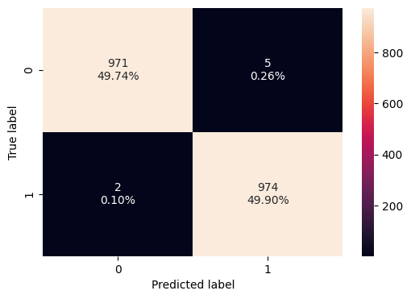

```python
# Creating the confusion matrix for the tuned model's performance on the undersampled training data.
confusion_matrix_sklearn(RF_un_tuned, X_train_un, y_train_un)
```

```python
# Checking the tuned model's performance metrics on the validation data.
model_performance_classification_sklearn(RF_un_tuned, X_val, y_val)
```

|  | Accuracy | Recall | Precision | F1 |
| --- | --- | --- | --- | --- |
| 0 | 0.930898 | 0.923313 | 0.723558 | 0.811321 |

```python
# Saving the tuned model's scores for later comparison.
RF_un_tuned_val_scores = model_performance_classification_sklearn(RF_un_tuned, X_val, y_val)
```

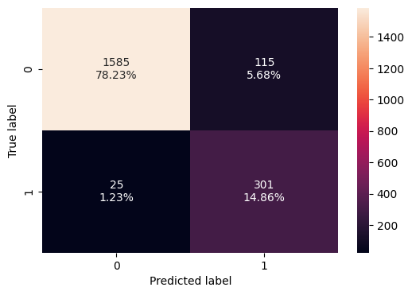

```python
# Creating the confusion matrix for the tuned model's performance on the validation data.
confusion_matrix_sklearn(RF_un_tuned, X_val, y_val)
```

**Adaboost in undersampled training data**

```python
# Defining the model.
Ada_un = AdaBoostClassifier(random_state=1)

# Creating the parameter grid to pass in RandomSearchCV.
param_grid = {
    "n_estimators": np.arange(50,110,25),
    "learning_rate": [0.01,0.1,0.05],
    "estimator": [ # Changed 'base_estimator' to 'estimator'
        DecisionTreeClassifier(max_depth=2, random_state=1),
        DecisionTreeClassifier(max_depth=3, random_state=1),
    ],
}

# Defining the scorer.
scorer = make_scorer(precision_score)

# Calling RandomizedSearchCV.
randomized_cv = RandomizedSearchCV(estimator=Ada_un, param_distributions=param_grid, n_iter=10, n_jobs = -1, scoring=scorer, cv=5, random_state=1)

# Fitting the parameters in RandomizedSearchCV.
randomized_cv.fit(X_train_un,y_train_un)

# Printing the best parameters from from the RandomizedSearchCV.
print("Best parameters are {} with CV score={}:" .format(randomized_cv.best_params_,randomized_cv.best_score_))
```

```
Best parameters are {'n_estimators': 100, 'learning_rate': 0.1, 'estimator': DecisionTreeClassifier(max_depth=3, random_state=1)} with CV score=0.9354785952552147:
```

```python
# Creating the tuned model with the best parameters found in RandomizedSearchCV.
Ada_un_tuned = AdaBoostClassifier(
    random_state=1,
    n_estimators=75,
    learning_rate=0.1,
    estimator=DecisionTreeClassifier(max_depth=2, random_state=1)) # Changed 'base_estimator' to 'estimator'

# Fitting the tuned model to the undersampled traning data.
Ada_un_tuned.fit(X_train_un, y_train_un)
```

```
AdaBoostClassifier(estimator=DecisionTreeClassifier(max_depth=2,
                                                    random_state=1),
                   learning_rate=0.1, n_estimators=75, random_state=1)
```

```python
# Checking the tuned model's performance metrics on the undersampled training data.
model_performance_classification_sklearn(Ada_un_tuned, X_train_un, y_train_un)
```

|  | Accuracy | Recall | Precision | F1 |
| --- | --- | --- | --- | --- |
| 0 | 0.95543 | 0.968238 | 0.944056 | 0.955994 |

```python
# Saving the tuned model's scores for later comparison.
Ada_un_tuned_train_scores = model_performance_classification_sklearn(Ada_un_tuned, X_train_un, y_train_un)
```

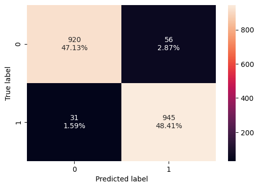

```python
# Creating the confusion matrix for the tuned model's performance on the undersampled training data.
confusion_matrix_sklearn(Ada_un_tuned, X_train_un, y_train_un)
```

```python
# Checking the tuned model's performance metrics on the validation data.
model_performance_classification_sklearn(Ada_un_tuned, X_val, y_val)
```

|  | Accuracy | Recall | Precision | F1 |
| --- | --- | --- | --- | --- |
| 0 | 0.930898 | 0.97546 | 0.706667 | 0.819588 |

```python
# Saving the tuned model's scores for later comparison.
Ada_un_tuned_val_scores = model_performance_classification_sklearn(Ada_un_tuned, X_val, y_val)
```

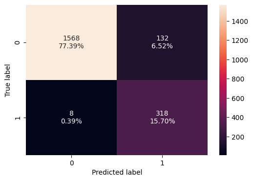

```python
# Creating the confusion matrix for the tuned model's performance on the validation data.
confusion_matrix_sklearn(Ada_un_tuned, X_val, y_val)
```

**Model Comparison and Final Model Selection**

```python
# Validation performance comparison.

# Assuming you have trained and validated AdaBoost on oversampled data
# and the results are stored in Ada_over_tuned_val_scores

# If you haven't, make sure to run the hyperparameter tuning and validation for AdaBoost on oversampled data first.

models_val_comp_df = pd.concat(
    [
        XGB_org_tuned_val_scores.T,
        GBC_org_tuned_val_scores.T,
        Ada_org_tuned_val_scores.T,
        XGB_over_tuned_val_scores.T,
        # Ada_over_tuned_val_scores.T, # This line is causing the error. Make sure Ada_over_tuned_val_scores is defined.
        GBC_over_tuned_val_scores.T,
        GBC_un_tuned_val_scores.T,
        RF_un_tuned_val_scores.T,
        Ada_un_tuned_val_scores.T,
    ],
    axis=1,
)
models_val_comp_df.columns = [
    "XGBoost trained with Original data",
    "Gradient boosting trained with Original data",
    "AdaBoost trained with Original data",
    "XGBoost trained with Oversampled data",
    # "AdaBoost trained with Oversampled data", # Remove or comment this line if Ada_over_tuned_val_scores is not defined.
    "Gradient boosting trained with Oversampled data",
    "Gradient boosting trained with Undersampled data",
    "Random Forest trained with Undersampled data",
    "AdaBoost trained with Undersampled data",
]
print("Validation performance comparison:")
models_val_comp_df
```

```
Validation performance comparison:
```

|  | XGBoost trained with Original data | Gradient boosting trained with Original data | AdaBoost trained with Original data | XGBoost trained with Oversampled data | Gradient boosting trained with Oversampled data | Gradient boosting trained with Undersampled data | Random Forest trained with Undersampled data | AdaBoost trained with Undersampled data |
| --- | --- | --- | --- | --- | --- | --- | --- | --- |
| Accuracy | 0.969891 | 0.939289 | 0.966930 | 0.957058 | 0.920039 | 0.895360 | 0.930898 | 0.930898 |
| Recall | 0.877301 | 0.815951 | 0.855828 | 0.907975 | 0.831288 | 0.920245 | 0.923313 | 0.975460 |
| Precision | 0.931596 | 0.808511 | 0.933110 | 0.838527 | 0.716931 | 0.617284 | 0.723558 | 0.706667 |
| F1 | 0.903633 | 0.812214 | 0.892800 | 0.871870 | 0.769886 | 0.738916 | 0.811321 | 0.819588 |

**Key Points** **Performance on Original Data**

**XGBoost** performs the best in terms of Accuracy (0.969891), Recall (0.877301), and F1-Score (0.903633).

This indicates it is well-suited for the original dataset.

AdaBoost achieves high Precision (0.933110), which means it makes fewer false positive predictions but sacrifices Recall slightly compared to XGBoost.

Gradient Boosting has the lowest performance across all metrics on the original data, particularly in Recall (0.815951) and Precision (0.808511).

**Performance on Oversampled Data**

Oversampling generally increases Recall for all models, as the dataset becomes more balanced.

Gradient Boosting and XGBoost show improvement in Recall (0.831288 and 0.907975, respectively), though Gradient Boosting's Precision drops significantly (0.716931).

**Performance on Undersampled Data**

Random Forest achieves high Recall (0.923313) and a decent Accuracy (0.930898), but its Precision (0.723558) is relatively lower, leading to an F1-Score of 0.811321.

AdaBoost on undersampled data achieves the highest Recall (0.975460), meaning it excels at identifying positive cases. However, its Precision (0.706667) is much lower, leading to an F1-Score (0.819588) that reflects this trade-off.

Gradient Boosting on undersampled data has a moderate Recall (0.920245) but struggles significantly with Precision (0.617284), resulting in a weaker F1-Score (0.738916).

**Insights** Original Data:

**XGBoost performs best overall with balanced performance across all metrics, making it the most reliable for unmodified datasets**

. **Gradient Boosting is less effective with imbalanced original data due to lower Recall and Precision.**

**Oversampled Data:**

**Undersampled Data:**

Undersampling significantly boosts Recall but often sacrifices Precision. This is particularly evident for AdaBoost and Gradient Boosting. Random Forest performs reasonably well, with a better balance between Recall and Precision compared to other models on undersampled data.

**Model Performance Comparison and Final Model Selection- Compare the performances of the tuned models - Choose the final model with a proper rationale - Comment on the performance of the best model on the test set**

**Test set Final Performance**

**HIGHEST PRECISION IS CONSIDERED ON TEST DATA**

```python
# Saving the top 3 tuned model's scores for later comparison.
XG_org_test_scores = model_performance_classification_sklearn(XGB_org_tuned, X_test, y_test)
Ada_un_tuned_test_scores = model_performance_classification_sklearn(Ada_un_tuned, X_test, y_test)
Ada_over_tuned_test_scores = model_performance_classification_sklearn(Ada_over_tuned, X_test, y_test)
```

```python
# Top 3 model test performance comparison.
models_test_comp_df = pd.concat(
    [
        XG_org_test_scores.T,
        Ada_un_tuned_test_scores.T,
        Ada_over_tuned_test_scores.T,
    ],
    axis=1,
)
models_test_comp_df.columns = [
      "XG Boost trained with Original Data",
      "AdaBoost trained with Undersampled data",
      "AdaBoost trained with Oversampled data"
]
print("Test performance comparison:")
models_test_comp_df
```

```
Test performance comparison:
```

|  | XG Boost trained with Original Data | AdaBoost trained with Undersampled data | AdaBoost trained with Oversampled data |
| --- | --- | --- | --- |
| Accuracy | 0.974827 | 0.926950 | 0.976802 |
| Recall | 0.910769 | 0.972308 | 0.938462 |
| Precision | 0.930818 | 0.694505 | 0.918675 |
| F1 | 0.920684 | 0.810256 | 0.928463 |

**1. XGBoost trained with Original Data**

**Accuracy:** 0.974827 (very high), indicating excellent overall classification performance.

**Recall:** 0.910769 (good), meaning it identifies most of the positive cases but misses some.

**Precision:** 0.930818 (high), indicating few false positives.

**F1-Score**: 0.920684 (strong), showing a good balance between Recall and Precision.

**Conclusion:** XGBoost on original data is highly reliable and balanced, with strong performance across all metrics.

**2. AdaBoost trained with Undersampled Data**

**Accuracy**: 0.926950 (lower than XGBoost and AdaBoost on oversampled data).

**Recall:** 0.972308 (highest among all models), meaning it is excellent at identifying positive cases.

**Precision:** 0.694505 (much lower), indicating a higher rate of false positives.

**F1-Score:** 0.810256 (lower than others), reflecting the imbalance between high Recall and low Precision.

**Conclusion:** AdaBoost with undersampled data focuses heavily on capturing positives (high Recall), but it sacrifices Precision significantly, leading to more false alarms.

**3. AdaBoost trained with Oversampled Data**

**Accuracy:** 0.976802 (highest among all models), meaning it classifies the test data most accurately overall.

**Recall:** 0.938462 (better than XGBoost, slightly lower than AdaBoost with undersampling), showing good detection of positives.

**Precision:** 0.918675 (very high), meaning it has a low rate of false positives.

**F1-Score:** 0.928463 (best overall), indicating excellent balance between Recall and Precision.

**Conclusion:** AdaBoost on oversampled data outperforms others by achieving both high Recall and high Precision, resulting in the best F1-Score

**The model with highest precision score on test data was chosen for final model.**

**This model was the XGBoost trained with Original data.**

```python
# Creating final model.
model_final = XGB_org_tuned
```

```python
# Checking the final tuned model's performance metrics on the test data.
model_performance_classification_sklearn(model_final, X_test, y_test)
```

|  | Accuracy | Recall | Precision | F1 |
| --- | --- | --- | --- | --- |
| 0 | 0.974827 | 0.910769 | 0.930818 | 0.920684 |

**This XGBoost model has 93% Precision**

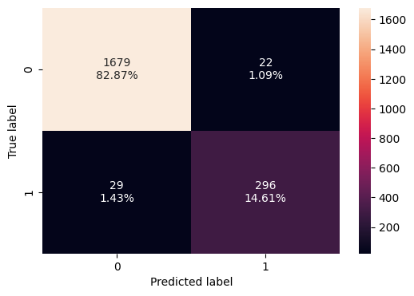

```python
# Creating the confusion matrix for the final tuned model's performance on the test data.
confusion_matrix_sklearn(model_final, X_test, y_test)
```

**By maximizing the Precision, the model sucessfully minimized False Positive (FP) occurrences.**

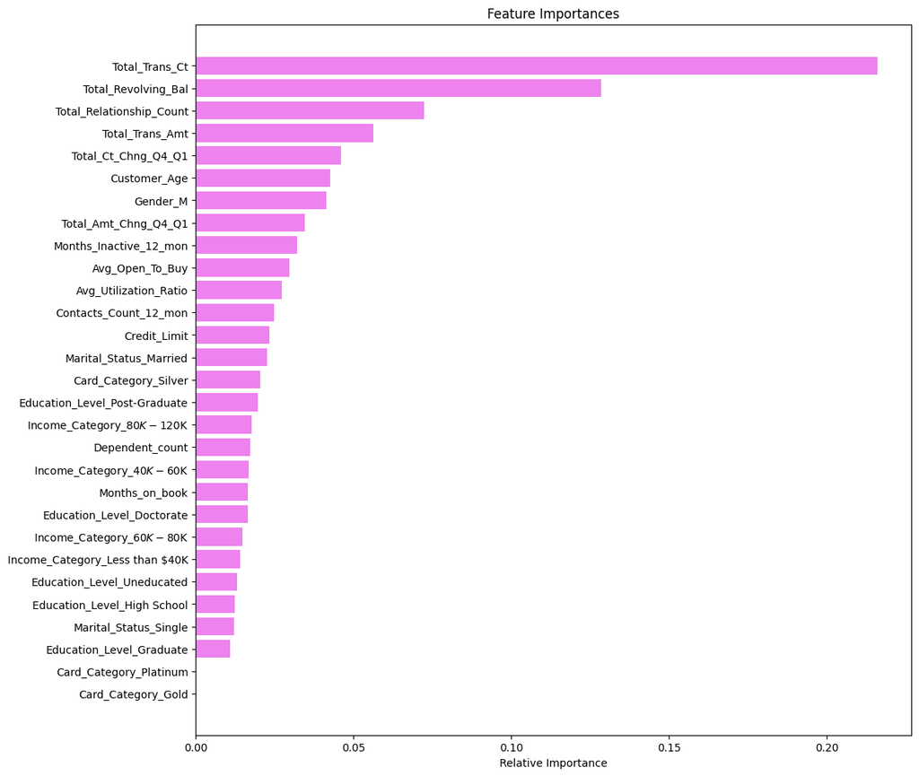

```python
# Creating a figure showing the relative importances of the independent variables.

feature_names = X_train.columns
importances =  model_final.feature_importances_
indices = np.argsort(importances)

plt.figure(figsize=(12, 12))
plt.title("Feature Importances")
plt.barh(range(len(indices)), importances[indices], color="violet", align="center")
plt.yticks(range(len(indices)), [feature_names[i] for i in indices])
plt.xlabel("Relative Importance")
plt.show()
```

**The most important features of the data set are:**

**Total_Trans_Amt**

**Total_Trans_Ct**

**Total_Revolving_Bal**

**Total_Ct_Chng_Q4_Q1**

**Total_Relationship_Ct**

**Actionable Insights & Recommendations- Write down insights from the analysis conducted - Provide actionable business recommendations**

**Actionable Insights**

Bank should connect with the customer more often to increase the connect, and provide the customer with various offers and schemes to increase relationships of the customer with the bank

Total_Ct_Chg_Q4_Q1 is higher for existing customers, indicating existing customers are more likely to spend later in the year than attrited customers. Attrited customers may use the card when they are pressured to do so financially and are only using the product out of necessity.

Customers with 1 or 2 products are more likely to attrit than those with 3 or more products. A potential strategy to retain customers could be to increase the strength of the bank's relationship with the customer by offering them additional products that the bank offers.

Customers with extreme Total_Revolving_Bal are likely to attrit. Customers with a very low revolving balance can easily pay off their balance and leave the product behind, but on the other side, customers with a very high revolving balance are more likely to be lost to default.

**Recommendations**

Bank should also offer credit limit increase for the customers who are regularly using the credit card. This should increase the credit card spends/transaction amounts.

0% interest EMI on credit card is also another offer that can be provided to customers to encourage the customers buy products of higher cost with credit card, and convert the expenditure to EMI, so that total transaction amount as well as transaction counts would increase. The balance would also revolve nicely.

Along with the available types of cards, bank can introduce credit cards specific to online shopping (with % cashback offers) or online food ordering. This way the card will be used more frequently.

Bank should offer cashback schemes on credit cards, which might encourage the customers on using the credit card more often